# Mochamad Hafid_MV2

#### Mochamad Hafid - 3E - 2213020268 - Praktikum Data Mining - Missing Value - #2

Tujuan Praktikum: mahasiswa mampu mengetahui, memahami, dan menerapkan Cleaning Data (Missing Values) dengan library scikit-learn

#### Percobaan dan Latihan

Langkah 1: Mengimpor library yang dibutuhkan

```python
import pandas as pd
import numpy as np
import missingno as msno
from sklearn.impute import SimpleImputer
```

Langkah 2: membaca file dataset bernama "datapegawai.csv" dan menyimpannya dalam variabel df sebagai DataFrame menggunakan library pandas.

```python
df = pd.read_csv('datapegawai.csv')
```

Langkah 3: Menampilkan isi DataFrame df yang telah dibaca sebelumnya dari file "datapegawai.csv".

```python
df
```

|  | Kota | Umur | MasaKerja | Gaji | Bonus |
| --- | --- | --- | --- | --- | --- |
| 0 | Surabaya | 27.0 | 9.0 | 51000.0 | Yes |
| 1 | Jakarta | 29.0 | 9.0 | 48000.0 | Yes |
| 2 | Surabaya | 30.0 | 5.0 | 52000.0 | No |
| 3 | Jakarta | 25.0 | 5.0 | 66000.0 | No |
| 4 | Kediri | 48.0 | 10.0 | NaN | Yes |
| 5 | Kediri | 33.0 | 8.0 | 51000.0 | No |
| 6 | Malang | 33.0 | 9.0 | 69000.0 | No |
| 7 | Jakarta | 40.0 | 10.0 | 79000.0 | Yes |
| 8 | Surabaya | 38.0 | NaN | NaN | Yes |
| 9 | Malang | 35.0 | NaN | 38000.0 | NaN |
| 10 | Kediri | 28.0 | 8.0 | 56000.0 | No |
| 11 | Malang | 35.0 | NaN | 72000.0 | No |
| 12 | Jakarta | NaN | 12.0 | 79000.0 | Yes |
| 13 | Surabaya | 31.0 | NaN | 85000.0 | NaN |
| 14 | Malang | 37.0 | 6.0 | 49000.0 | No |
| 15 | Malang | 12.0 | 6.0 | 50000.0 | No |
| 16 | Surabaya | 40.0 | 11.0 | 69000.0 | Yes |
| 17 | Jakarta | 95.0 | NaN | 86000.0 | NaN |
| 18 | Kediri | 50.0 | NaN | NaN | Yes |
| 19 | Surabaya | 31.0 | NaN | NaN | No |
| 20 | Surabaya | NaN | 4.0 | 68000.0 | Yes |
| 21 | Kediri | 41.0 | 6.0 | 75000.0 | Yes |
| 22 | Kediri | 29.0 | NaN | 70000.0 | No |

Langkah 3: Menghitung jumlah nilai kosong (null) di setiap kolom dalam DataFrame df.

```python
df.isnull().sum()
```

```
Kota         0
Umur         2
MasaKerja    8
Gaji         4
Bonus        3
dtype: int64
```

Langkah 4: Menampilkan visualisasi matriks yang menunjukkan distribusi nilai kosong (null) dalam DataFrame df menggunakan library missingno.

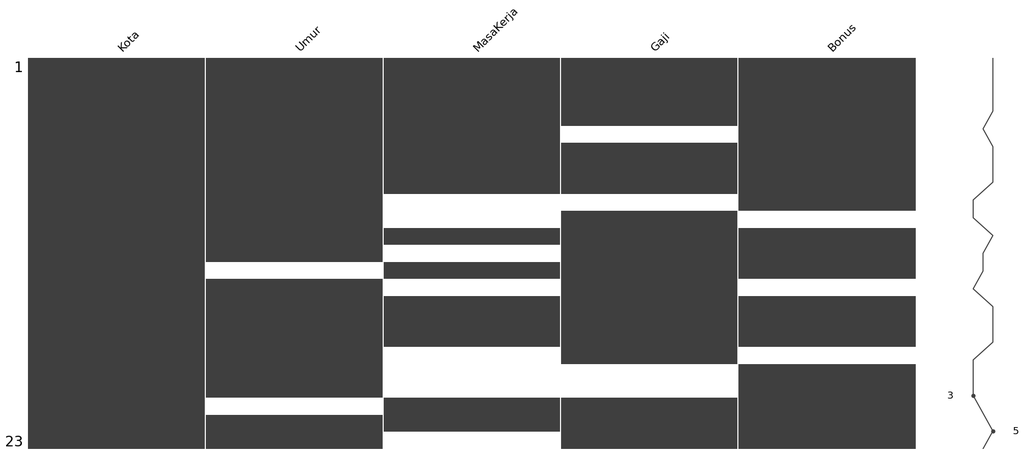

```python
msno.matrix(df)
```

Langkah 5: Mengisi nilai kosong (null) pada kolom kedua DataFrame df dengan nilai rata-rata (mean) menggunakan SimpleImputer dari sklearn.impute.

```python
imputer = SimpleImputer(missing_values=np.nan,strategy='mean')
imputer.fit(df.iloc[:,1:2])
df.iloc[:,1:2] = imputer.transform(df.iloc[:,1:2])
```

```python
df
```

|  | Kota | Umur | MasaKerja | Gaji | Bonus |
| --- | --- | --- | --- | --- | --- |
| 0 | Surabaya | 27.00000 | 9.0 | 51000.0 | Yes |
| 1 | Jakarta | 29.00000 | 9.0 | 48000.0 | Yes |
| 2 | Surabaya | 30.00000 | 5.0 | 52000.0 | No |
| 3 | Jakarta | 25.00000 | 5.0 | 66000.0 | No |
| 4 | Kediri | 48.00000 | 10.0 | NaN | Yes |
| 5 | Kediri | 33.00000 | 8.0 | 51000.0 | No |
| 6 | Malang | 33.00000 | 9.0 | 69000.0 | No |
| 7 | Jakarta | 40.00000 | 10.0 | 79000.0 | Yes |
| 8 | Surabaya | 38.00000 | NaN | NaN | Yes |
| 9 | Malang | 35.00000 | NaN | 38000.0 | NaN |
| 10 | Kediri | 28.00000 | 8.0 | 56000.0 | No |
| 11 | Malang | 35.00000 | NaN | 72000.0 | No |
| 12 | Jakarta | 36.52381 | 12.0 | 79000.0 | Yes |
| 13 | Surabaya | 31.00000 | NaN | 85000.0 | NaN |
| 14 | Malang | 37.00000 | 6.0 | 49000.0 | No |
| 15 | Malang | 12.00000 | 6.0 | 50000.0 | No |
| 16 | Surabaya | 40.00000 | 11.0 | 69000.0 | Yes |
| 17 | Jakarta | 95.00000 | NaN | 86000.0 | NaN |
| 18 | Kediri | 50.00000 | NaN | NaN | Yes |
| 19 | Surabaya | 31.00000 | NaN | NaN | No |
| 20 | Surabaya | 36.52381 | 4.0 | 68000.0 | Yes |
| 21 | Kediri | 41.00000 | 6.0 | 75000.0 | Yes |
| 22 | Kediri | 29.00000 | NaN | 70000.0 | No |

Mengisi nilai kosong (null) pada kolom kedua DataFrame df dengan nilai rata-rata (mean) menggunakan SimpleImputer dalam satu langkah.

```python
imputer = SimpleImputer(missing_values=np.nan,strategy='mean')

df.iloc[:,1:2] = imputer.fit_transform(df.iloc[:,1:2])
```

```python
df
```

|  | Kota | Umur | MasaKerja | Gaji | Bonus |
| --- | --- | --- | --- | --- | --- |
| 0 | Surabaya | 27.00000 | 9.0 | 51000.0 | Yes |
| 1 | Jakarta | 29.00000 | 9.0 | 48000.0 | Yes |
| 2 | Surabaya | 30.00000 | 5.0 | 52000.0 | No |
| 3 | Jakarta | 25.00000 | 5.0 | 66000.0 | No |
| 4 | Kediri | 48.00000 | 10.0 | NaN | Yes |
| 5 | Kediri | 33.00000 | 8.0 | 51000.0 | No |
| 6 | Malang | 33.00000 | 9.0 | 69000.0 | No |
| 7 | Jakarta | 40.00000 | 10.0 | 79000.0 | Yes |
| 8 | Surabaya | 38.00000 | NaN | NaN | Yes |
| 9 | Malang | 35.00000 | NaN | 38000.0 | NaN |
| 10 | Kediri | 28.00000 | 8.0 | 56000.0 | No |
| 11 | Malang | 35.00000 | NaN | 72000.0 | No |
| 12 | Jakarta | 36.52381 | 12.0 | 79000.0 | Yes |
| 13 | Surabaya | 31.00000 | NaN | 85000.0 | NaN |
| 14 | Malang | 37.00000 | 6.0 | 49000.0 | No |
| 15 | Malang | 12.00000 | 6.0 | 50000.0 | No |
| 16 | Surabaya | 40.00000 | 11.0 | 69000.0 | Yes |
| 17 | Jakarta | 95.00000 | NaN | 86000.0 | NaN |
| 18 | Kediri | 50.00000 | NaN | NaN | Yes |
| 19 | Surabaya | 31.00000 | NaN | NaN | No |
| 20 | Surabaya | 36.52381 | 4.0 | 68000.0 | Yes |
| 21 | Kediri | 41.00000 | 6.0 | 75000.0 | Yes |
| 22 | Kediri | 29.00000 | NaN | 70000.0 | No |

Langkah 6: Mengisi nilai kosong (null) pada kolom ketiga dan keempat DataFrame df dengan nilai median menggunakan SimpleImputer

```python
imputer = SimpleImputer(missing_values=np.nan,strategy='median')

df.iloc[:,2:4] = imputer.fit_transform(df.iloc[:,2:4])
```

```python
df
```

|  | Kota | Umur | MasaKerja | Gaji | Bonus |
| --- | --- | --- | --- | --- | --- |
| 0 | Surabaya | 27.00000 | 9.0 | 51000.0 | Yes |
| 1 | Jakarta | 29.00000 | 9.0 | 48000.0 | Yes |
| 2 | Surabaya | 30.00000 | 5.0 | 52000.0 | No |
| 3 | Jakarta | 25.00000 | 5.0 | 66000.0 | No |
| 4 | Kediri | 48.00000 | 10.0 | 68000.0 | Yes |
| 5 | Kediri | 33.00000 | 8.0 | 51000.0 | No |
| 6 | Malang | 33.00000 | 9.0 | 69000.0 | No |
| 7 | Jakarta | 40.00000 | 10.0 | 79000.0 | Yes |
| 8 | Surabaya | 38.00000 | 8.0 | 68000.0 | Yes |
| 9 | Malang | 35.00000 | 8.0 | 38000.0 | NaN |
| 10 | Kediri | 28.00000 | 8.0 | 56000.0 | No |
| 11 | Malang | 35.00000 | 8.0 | 72000.0 | No |
| 12 | Jakarta | 36.52381 | 12.0 | 79000.0 | Yes |
| 13 | Surabaya | 31.00000 | 8.0 | 85000.0 | NaN |
| 14 | Malang | 37.00000 | 6.0 | 49000.0 | No |
| 15 | Malang | 12.00000 | 6.0 | 50000.0 | No |
| 16 | Surabaya | 40.00000 | 11.0 | 69000.0 | Yes |
| 17 | Jakarta | 95.00000 | 8.0 | 86000.0 | NaN |
| 18 | Kediri | 50.00000 | 8.0 | 68000.0 | Yes |
| 19 | Surabaya | 31.00000 | 8.0 | 68000.0 | No |
| 20 | Surabaya | 36.52381 | 4.0 | 68000.0 | Yes |
| 21 | Kediri | 41.00000 | 6.0 | 75000.0 | Yes |
| 22 | Kediri | 29.00000 | 8.0 | 70000.0 | No |

Langkah 7: Mengisi nilai kosong (null) pada kolom kategorikal di DataFrame df dengan nilai yang paling sering muncul (modus) menggunakan SimpleImputer

```python
imputer_cat = SimpleImputer(missing_values=np.nan,strategy='most_frequent')

df.iloc[:,4:] = imputer_cat.fit_transform(df.iloc[:,4:])
```

```python
df
```

|  | Kota | Umur | MasaKerja | Gaji | Bonus |
| --- | --- | --- | --- | --- | --- |
| 0 | Surabaya | 27.00000 | 9.0 | 51000.0 | Yes |
| 1 | Jakarta | 29.00000 | 9.0 | 48000.0 | Yes |
| 2 | Surabaya | 30.00000 | 5.0 | 52000.0 | No |
| 3 | Jakarta | 25.00000 | 5.0 | 66000.0 | No |
| 4 | Kediri | 48.00000 | 10.0 | 68000.0 | Yes |
| 5 | Kediri | 33.00000 | 8.0 | 51000.0 | No |
| 6 | Malang | 33.00000 | 9.0 | 69000.0 | No |
| 7 | Jakarta | 40.00000 | 10.0 | 79000.0 | Yes |
| 8 | Surabaya | 38.00000 | 8.0 | 68000.0 | Yes |
| 9 | Malang | 35.00000 | 8.0 | 38000.0 | No |
| 10 | Kediri | 28.00000 | 8.0 | 56000.0 | No |
| 11 | Malang | 35.00000 | 8.0 | 72000.0 | No |
| 12 | Jakarta | 36.52381 | 12.0 | 79000.0 | Yes |
| 13 | Surabaya | 31.00000 | 8.0 | 85000.0 | No |
| 14 | Malang | 37.00000 | 6.0 | 49000.0 | No |
| 15 | Malang | 12.00000 | 6.0 | 50000.0 | No |
| 16 | Surabaya | 40.00000 | 11.0 | 69000.0 | Yes |
| 17 | Jakarta | 95.00000 | 8.0 | 86000.0 | No |
| 18 | Kediri | 50.00000 | 8.0 | 68000.0 | Yes |
| 19 | Surabaya | 31.00000 | 8.0 | 68000.0 | No |
| 20 | Surabaya | 36.52381 | 4.0 | 68000.0 | Yes |
| 21 | Kediri | 41.00000 | 6.0 | 75000.0 | Yes |
| 22 | Kediri | 29.00000 | 8.0 | 70000.0 | No |

Cara lain yaitu Mengisi nilai kosong (null) pada kolom terakhir DataFrame df dengan nilai tetap "Sedang" menggunakan SimpleImputer

```python
# imputer_cat = SimpleImputer(missing_values=np.nan,strategy='constant',fill_value='Sedang')

# df.iloc[:,4:] = imputer_cat.fit_transform(df.iloc[:,4:])
```

# Analisa Hasil Percobaan

## 1. Pemeriksaan Missing Values

- Menggunakan df.isnull().sum() untuk melihat jumlah nilai kosong di setiap kolom.
- Visualisasi dengan msno.matrix(df) menunjukkan distribusi nilai kosong dalam DataFrame.

## Kesimpulan

Pandas digunakan untuk membaca, mengolah, dan menganalisis data dalam bentuk DataFrame. Jika ada data yang hilang, pandas menyediakan metode seperti fillna(), dropna(), atau interpolate().

Sedangkan SimpleImputer dari scikit-learn dirancang khusus untuk menangani data yang hilang dengan strategi tertentu (mean, median, modus, atau nilai tetap) dan sering digunakan dalam pipeline machine learning untuk memastikan data siap digunakan dalam model.